**Enveloppe Convexe : marche de Jarvis**

Haude Aucéane - Da Costa Antoine

[figure not shown]

**Enveloppe convexe : marche de Jarvis**

Niveau : ★

Description : En géométrie algorithmique la marche de Jarvis est un algorithme permettant de calculer l'enveloppe convexe d'un nuage de point.

Animation : Les différentes étapes de l'algorithme.

Dans ce devoir nous avons passer beaucoup de temps a chercher comment représenter et mettre en place la marche de Javis. Nous espérons que le résultat vous plaira.

Il y a beaucoup de fonction qui seront faite afin de faire une certainne fluidité.

**Bibliothèques**

```python
from random import *


from matplotlib.pyplot import *
from IPython.display import HTML
from matplotlib import animation
```

**Sommaire :**

- Partie 1 : y la droite d'équation linéaire
  - A. Le a
  - B. Le point b
  - C. La droite d'équation y=ax+b
  - D. Génération de points
  - E. Test de ' y ' avec les points généré
- Partie 2 : Les Fonctions utiles
  - A. Tableau de Y
  - B. Toutes les valeurs x et y
  - C. Les Fonctions Minimum-Maximum
  - D. Les points d'un x
- Partie 3 : Enveloppe convexe
  - A. "Le point le plus à gauche"
  - B. Le point initial
  - C. L'Enveloppe Convexe : La Marche de Javis
- Partie 4: Animation
  - A. Petite modification
  - B. Fonction Fantaisie
  - C. Animation
- Conclusion

**Partie 1 : y la droite d'équation linéaire**

Au tout début nous voulions prendre l'algorithme de Brelaz mais étant plusieurs on en a choisi un autre : La marche de Javis

Au tout début nous nous sommes demandé comment faire car on doit faire une enveloppe qui couvre tous les points.

En cherchant sur internet ils disaient, prendre "le point le plus a gauche", nous nous sommes demandé comment ??

Nous avons fait des tests dans mon coin est essayé de comprendre comment faire, nous avons observé et trouvé une solution !!

Le point le plus à gauche est, en combinant avec le point de départ, le point avec lequel il a l'équation linéaire la plus grande !!

Donc il faut utilisé l'équation y=ax+b !!

Et qu'il faudrait donc se basé sur le a de l'équation pour trouvé le point !!

**A. Le a**

Une formule très connue que l'on peut utilisé pour trouver ce a est a=(y2-y1)/(x2-x1) !!

Donc je vais faire la fonction a(point1,point2) afin de voir cela :

```python
def a(point1,point2):
    """
    Prend en paramètre deux points
        et retourne le coefficient
        dirrecteur de la droite
        d'équation y=ax+b.
    """
    return (point2[1]-point1[1])/(point2[0]-point1[0])
```

**B. Le point b**

Le problème, c'est qu'en testant de notre côté, certaines équations peuvent avoir le même a et donc cela veut dire que nous avons aussi besoin du b, mais je me suis dit comment calculer le b !!

Il y a bien des méthodes à l'écrit mais que les ordinateurs ne peuvent pas utiliser !!

Donc en y réfléchissant nous nous sommes rappelé qu'il y avait la formule y=ax+b donc connaissant le a et les coordonnées x et y des 2 points, et que donc on peut utiliser par exemple le premier point et qu'on appliquerait la formule mais pour obtenir b!!

b=y-ax !!

Donc, avec cela, nous allons faire la fonction b(a,point1) :

```python
def b(a,point1):
    """
    Prend en paramètre deux valeurs,
        une renvoyer par la première fonction
        et l'autre est le premier point donné
        en paramètre dans la fonction 'a'.
    Et retourne l’ordonnée à l’origine de la
        droite d'équation y=ax+b.
    """
    return point1[1]-a*point1[0]
```

**C. La droite d'équation y=ax+b**

La fonction ' b ' étant faites, sachant qu'on a déjà la ' a ', on a besoin de les placer dans une variable afin de les conserver.

Ces valeurs sont faites pour déduire la droite d'équation y=ax+b. Donc on pourrait les mettres dans une fonction ' y '.

La fonction ' y ' prend en paramètre deux points et renvois un tableau contenant la valeur a et la valeur b renvoyée par les deux dernières fonctions :

```python
def y(point1,point2):
    """
    Prend en paramètre deux points distinct.
    La fonction retourne un tableau contenant
        les valeurs a et b.
    La fonction 'y' représente la droite
    d'équation y=ax+b.
    """
    if point1[0]==point2[0]:
        return [-10000,10000] # cette ligne ne sert a rien apart pour comblé et éviter les erreurs
    Ytab=[]
    A=a(point1,point2)
    B=b(A,point1)
    Ytab.append(A)
    Ytab.append(B)
    return Ytab
```

**D. Génération de points**

Maintenant, afin de tester les nouvelles fonctions, je vais avoir besoin de points !!

Donc je vais créé plusieurs listes de points !!

Les points seront contenus dans une liste et se composeront de la manière suivante : [x,y]

Pour créer cette liste de points on va créer une fonction qui va générer aléatoirement un tableau de 5 à 100 points avec des valeurs allant de 0 à 50 pour les x et y.

Il ne peut y avoir dedans des points doublons !!

```python
def creePoint() :
    """
    Ne prend aucun paramètre.
    Renvoie un tableau de tableaux
        ayant comme valeur l'intérieur
        des points x et y.
    Aucun des tableaux a l'intérieur du
        tableau rendu n'aura de doublons !!
    """
    TabPoints=[]
    nb_points=randint(5,100)
    i=0
    while i<nb_points:
        point=[randint(0,50),randint(0,50)]
        if point not in TabPoints:
            TabPoints.append(point)
        else:
            i-=1
        i+=1
    return TabPoints
```

**E. Test de ' y ' avec les points généré**

```
Voici le premier tableau de points créer:

 [[49, 22], [13, 48], [12, 18], [5, 44], [46, 21], [50, 6], [48, 46], [44, 23], [38, 43], [19, 23], [0, 15], [47, 4], [16, 41], [0, 4], [11, 8], [17, 38], [34, 11], [18, 44], [11, 42], [35, 37], [46, 31], [28, 5], [23, 47], [10, 47], [41, 41], [23, 16], [32, 39], [27, 50], [36, 22], [18, 46], [24, 4…

Tout d'abord faisont un test simple :
Premier test avec : firstTest[0] =  [49, 22]

Prennons en deuxième point : firstTest[7] =  [44, 23]

Maintenant, déduisons leurs droite d'équation y=ax+b avec y ( [49, 22] , [44, 23] )
y ( [49, 22] , [44, 23] ) =  [-0.2, 31.8]


Maintenant, faisont directement une comparaison avec une courbe.
```

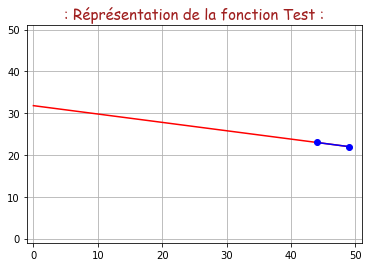

```
Comme on peut le voir le point a l'origine, lorsque x=0 est bien d'environs 31.8 !
a*ft2[0]+b =  23.0
Et ft2[1] = 23
Et notre courbe passe bien par nos deux points !!
La fonction a été vérifié et donne bien le bon résultat !!
```

```python
#firstTest=creePoint()
print("Voici le premier tableau de points créer:\n\n",firstTest)
print("\nTout d'abord faisont un test simple :","\nPremier test avec : firstTest[0] = ",firstTest[0])

print("\nPrennons en deuxième point : firstTest[7] = ",firstTest[7])
print("\nMaintenant, déduisons leurs droite d'équation y=ax+b avec y (",firstTest[0],",",firstTest[7],")")
print("y (",firstTest[0],",",firstTest[7],") = ", y(firstTest[0],firstTest[7]))
print("\n\nMaintenant, faisont directement une comparaison avec une courbe.")
ft1=firstTest[0]
ft2=firstTest[7]
y1= y(ft1,ft2)
X=[k for k in range(50)]
Y=[y1[0]*x+y1[1] for x in X]
X1=[ft1[0],ft2[0]]
Y1=[ft1[1],ft2[1]]
font1={"family" : "fantasy", "color" : "#9F1F1F","size":15}
title(": Réprésentation de la fonction Test :", fontdict=font1)
ylim(-1, 51)
xlim(-1, 51)
plot(X, Y, color='red')
plot(X1,Y1,marker="o",color='blue')
grid(True)
show()

print("Comme on peut le voir le point a l'origine, lorsque x=0 est bien d'environs",y1[1],"!")
print("a*ft2[0]+b = ",y1[0]*ft2[0]+y1[1],"\nEt ft2[1] =",ft2[1])
print("Et notre courbe passe bien par nos deux points !!")
print("La fonction a été vérifié et donne bien le bon résultat !!\n")
```

**Partie 2 : Les Fonctions utiles**

**A. Tableau de Y**

En fonction utile on pourrait faire la fonction ' ys ' qui prend en paramètre donc un point et le tableau de points et renvoie toutes les droites équations y=ax+b disponible pour le point donné.

```python
def ys(P,points):
    """
    Prend en paramètre un point et le tableau d'où il provient.
    Renvoie toute les possibilité de droite d'équation y=ax+b
        du point en question, donnant donc l'équation de la droite
        disponible avec chacun des autres points.
    Avec ces points il renvois aussi une valeur j qui dit quel est
        le point avec lequel il a été testé, j est l'indice du point.
    """
    Ys=[]
    j=0
    for i in points:
        if i == P:
            Ys.append([0,0,j])
        else :
            Y=y(P,i)
            Y.append(j)
            Ys.append(Y)
        j+=1
    return Ys
```

Test :

On va reprendre la valeur firstTest :

```python
firstTest=[[49, 22], [13, 48], [12, 18], [5, 44], [46, 21], [50, 6], [48, 46], [44, 23], [38, 43], [19, 23], [0, 15], [47, 4], [16, 41], [0, 4], [11, 8], [17, 38], [34, 11], [18, 44], [11, 42], [35, 37], [46, 31], [28, 5], [23, 47], [10, 47], [41, 41], [23, 16], [32, 39], [27, 50], [36, 22], [18, 46], [24, 48], [3, 19], [4, 34], [48, 17], [10, 50], [14, 19], [29, 38], [47, 47], [27, 23], [39, 35], [29, 4], [15, 1], [37, 4], [8, 18], [9, 4], [1, 40], [25, 1], [20, 21]]
```

Maintenant, reprennont le point firstTest[ 0 ], qui est [ 49 , 22 ], et le point firstTest[ 7 ], qui est [ 44 , 23 ] :

```python
y1=y(firstTest[0],firstTest[7])
print("firstTest[0] = ",firstTest[0])
print("firstTest[7] = ",firstTest[7])
print("\ny (",firstTest[0],",",firstTest[7],") = ", y1)
print("\n\nMaintenant observons :\n")
print("On a dans l'équation de ses deux dernier y =",y1[0],"* x +",y1[1])
print("Or on sait aussi que au troisième emplacement de la fonction 'ys' l'indice du point testé")
print("Imaginons, si on fait ys(firstTest[0],firstTest) alors notre 'y' testé auparavant \nSerait situé a l'indice 7 de la fonction précédente mais aurait donc aussi 7 en 3ème valeur dans sa case !!")
print("\n\nTestons :")
ys1=ys(firstTest[0],firstTest)
print("ys(firstTest[0],firstTest) =\n\n",ys1)
print("\nEt nous avont a l'indice 7 :",ys1[7],"\nQui est notre valeur attendu !!\nNotre fonction fonctionne bien !!")
```

```
firstTest[0] =  [49, 22]
firstTest[7] =  [44, 23]

y ( [49, 22] , [44, 23] ) =  [-0.2, 31.8]


Maintenant observons :

On a dans l'équation de ses deux dernier y = -0.2 * x + 31.8
Or on sait aussi que au troisième emplacement de la fonction 'ys' l'indice du point testé
Imaginons, si on fait ys(firstTest[0],firstTest) alors notre 'y' testé auparavant
Serait situé a l'indice 7 de la fonction précédente mais aurait donc aussi 7 en 3ème valeur dans sa case !!


Testons :
ys(firstTest[0],firstTest) =

 [[0, 0, 0], [-0.7222222222222222, 57.388888888888886, 1], [0.10810810810810811, 16.7027027027027, 2], [-0.5, 46.5, 3], [0.3333333333333333, 5.666666666666668, 4], [-16.0, 806.0, 5], [-24.0, 1198.0, 6], [-0.2, 31.8, 7], [-1.9090909090909092, 115.54545454545455, 8], [-0.03333333333333333, 23.63333333…

Et nous avont a l'indice 7 : [-0.2, 31.8, 7]
Qui est notre valeur attendu !!
Notre fonction fonctionne bien !!
```

**B. Toutes les valeurs x et y**

Afin d'arranger des calculs nous avons pensé nécessaire pour l'analyse de faire des fonctions renvoyant respectivement :

- Pour xta, un tableau constitué de tous les x du tableau donné.
- Pour yta, nn tableau constitué de tous les y du tableau donné.

Ils prennent tous deux en paramètre un tableau constituer de points.

```python
def xta(tab):
    """
    Prend en paramètre un tableau de points.
    Renvois un tableau de valeur x.
    """
    xtab=[]
    i=0
    while i <len(tab):
        xtab.append(tab[i][0])
        i+=1
    return xtab
```

```python
def yta(tab):
    """
    Prend en paramètre un tableau de points.
    Renvois un tableau de valeur y.
    """
    ytab=[]
    i=0
    while i <len(tab):
        ytab.append(tab[i][1])
        i+=1
    return ytab
```

**C. Les Fonctions Minimum-Maximum**

On a pensé aussi utile de prendre les valeurs minimums et maximums de x et y, afin de pouvoir fixé des limites plus tard.

Alors pour cela, on va créer les fonctions xm et ym qui renverons un tableau contenant la valeur minimale et maximale de leurs abscisses associées.

```python
def xm(tab):
    """
    Prend en paramètre un tableau de points.
    Renvois un tableau comportant 2 valeurs :
        - la valeur minimum de x
        - la valeur maximum de x
    """
    tabx=xta(tab)
    xmax=tabx[0]
    xmin=tabx[0]
    xminmax=[]
    i=1
    while i<len(tab):
        if tabx[i]<xmin:
            xmin=tabx[i]
        if tabx[i]>xmax:
            xmax=tabx[i]
        i+=1
    xminmax.append(xmin)
    xminmax.append(xmax)
    return xminmax
```

```python
def ym(tab):
    """
    Prend en paramètre un tableau de points.
    Renvois un tableau comportant 2 valeurs :
        - la valeur minimum de y
        - la valeur maximum de y
    """
    taby=yta(tab)
    ymax=taby[0]
    ymin=taby[0]
    yminmax=[]
    i=1
    while i<len(tab):
        if taby[i]<ymin:
            ymin=taby[i]
        if taby[i]>ymax:
            ymax=taby[i]
        i+=1
    yminmax.append(ymin)
    yminmax.append(ymax)
    return yminmax
```

**D. Les points d'un x**

Il nous faudrait une fonction qui permettrait de donner un tableau constituer des points a la même abscisse.

Ce tableau pourrait être donné par la fonction ys_x qui prend en paramètre un point et le tableau duquel il vient afin de donner en retour un tableau constituer de tous les autres points que lui-même ayant la même abscisse, mais ne peut prendre le point donner en paramètre.

```python
def ys_de_x(point1,points):
    """
    Prend en paramètre un point et le tableau d'où il provient.
    Renvois le tableau constituer de toutes les autres points que
        lui même ayant la même abscisse,
        mais ne peut prendre le point donner en paramètre.
    """
    i=0
    ysx=[]
    while i<len(points):
        if points[i][0]==point1[0] and points[i]!=point1:
            ysx.append(points[i])
        i+=1
    return ysx
```

**Partie 3 : Enveloppe convexe**

**A. "Le point le plus à gauche"**

D'après ce qui est dit sur internet de l'enveloppe convexe, la marche de Javis, il faut être capable de montrer le "point le plus à gauche", d'un point choisi, donc nous allons créer la fonction pgauche !!

Cette fonction est la plus complexe car on doit être capable de trouver ce point !!

Toutes les fonctions précédentes seront utilisées à un moment ou un autre mais surtout dans celle-là !!

Cette fonction a été modifié beaucoup de fois afin d'être perfectionné !!

Dire de trouver "le point le plus à gauche" n'est pas quelque chose de simple, car il faut comprendre ce morceau de phrase !!

Afin de le comprendre nous avons fait des tests, de multiple, afin d'observer certains comportements et comprendre comment trouver ce point !!

Les fonctions précédentes nous seront utiles car pour trouver ce point il faut beaucoup de critère :

- Avoir le coefficient directeur le plus haut
- Si le même coefficient directeur, comparer les ordonnées à l’origine
- Savoir où on se situe dans le graphe
- Vérifié toutes les possibilités

Pour cela on va donc créer la fonction pgauche qui prend en paramètre :

- Un point
- Le tableau d'où provient le point
- l'avancer

L'avancer est une valeur booléenne qui sera modifiée plus tard qui a pour but d'orienter la recherche du point le plus à gauche. La fonction pgauche renverra le point le plus à gauche trouvé !!

```python
def pgauche(point1,points,avancer):
    """
    Prend en paramètre un point, le tableau d'où il vient,
        et une valeur booléenne.
    Et retourne un point supposer être le plus a gauche.
    """
    Ys=ys(point1,points)
    i=0
    Xmm=xm(points)
    Ymm=xm(Ys)
    p=point1
    ys_x=ys_de_x(point1,points)
    py=[Ymm[0]-1,Ymm[1]+1]
    j=0
    if len(ys_x)!=0:
        if p[0]==Xmm[1] :
            if ym(ys_x)[0]!=p[1] and ym(ys_x)[0]<p[1]:
                p=ys_x[0]
    while i<len(points) and j<=len(ys_x) :
        if points[Ys[i][2]]!=point1:

            if point1[0]==Xmm[0] and avancer==True:
                if Ys[i][0]>py[0] :
                    py=Ys[i]
                    p=points[py[2]]


            elif point1[0]>Xmm[0] and points[i][0]>point1[0] and avancer==True:

                if Ys[i][0]==py[0] and Ys[i][1]>py[1] and p[0]>points[i][0]:
                    py=Ys[i]
                    p=points[py[2]]

                elif Ys[i][0]>py[0] :
                    py=Ys[i]
                    p=points[py[2]]


            elif point1[0]==Xmm[1] and avancer==False and len(ys_x)!=0 and j<len(ys_x) and p==ys_x[0]:
                if ys_x[j][1]>p[1] and point1[1]>ys_x[j][1]:
                    p=ys_x[j]
                    py=Ys[points.index(p)]
                j+=1


            elif point1[0]==Xmm[1] and avancer==False and len(ys_x)!=0 :
                if points[i][1]<point1[1] and Ys[i][0]>py[0] and p!=ys_x[0] :

                    py=Ys[i]
                    p=points[py[2]]


            elif point1[0]==Xmm[1] and avancer==False and len(ys_x)==0:

                if points[i][0]<point1[0]  and Ys[i][0]>py[0] :

                    py=Ys[i]
                    p=points[py[2]]


            elif point1[0]<Xmm[1] and point1[0]!=Xmm[0] and points[i][0]<point1[0] and avancer==False :
                if Ys[i][1]==py[1] and Ys[i][0]==py[0] and p[0]<points[i][0]:
                    py=Ys[i]
                    p=points[py[2]]


                elif Ys[i][0]>py[0] :

                    py=Ys[i]
                    p=points[py[2]]


            elif point1[0]==Xmm[0] and avancer==False and len(ys_x)!=0 and j<len(ys_x) and p!=ys_x[0] :
                if ys_x[j][1] > p[1] and point1[1] <  ys_x[j][1]:
                    p=ys_x[j]
                    py=Ys[points.index(p)]
                j+=1

        i+=1
    return p
```

Nous allons tester plus tard la fonction afin de pouvoir donné des résultats plus corrects et visibles.

**B. Le point initial**

Afin de trouver le point initial nous n'allons pas utiliser la fonction pgauche, nous allons chercher le point ayant l'abscisse la plus basse et l'ordonnée la plus haute !

La fonction pinit prendra en paramètre un tableau de points et retournera la valeur initiale.

```python
def pinit(points):
    """
    Prend en paramètre un tableau de points.
    Retourne le point supposer initial.
    """
    i=1
    p=points[0]
    while i<len(points):
        if p[0]>points[i][0]:
            p=points[i]
        if p[0]==points[i][0] and p[1]<points[i][1]:
            p=points[i]
        i+=1
    return p
```

**C. L'Enveloppe Convexe : La Marche de Javis**

Enfin nous pouvons faire cette fonction !

La fonction donnera tous les points de l'enveloppe convexe !

C'est la fonction qui nous permettra de faire l'animation !

Nous allons donc faire une fonction qui utilise les fonctions précédentes afin de faire l'enveloppe convexe.

Cette fonction s'appellera ArbreC et prendra en paramètre le tableau de points à tester, et renverra un tableau constituer des points de l'enveloppe convexe !!

Afin de faire cela elle va manipuler le tableau, déterminer les valeurs minimales et maximales de celui-ci, gérer l'avancement afin de trouver les bons points dans la fonction pgauche et s'arrêter lorsque le point le plus à gauche atteigne le point initial.

```python
def ArbreC(points):
    """
    Prend en paramètre un tableau de points.
    Retourne un tableau constituer des points
        de l'enveloppe convexe du tableau mis
        en paramètre.
    """
    initp=pinit(points)
    listefinal=[]
    listefinal.append(initp)
    avancer=True
    Xmm=xm(points)
    pg=initp
    i=0
    TF=True
    while i<len(listefinal)and TF==True:
        pg=pgauche(listefinal[i],points,avancer)
        if pg!=initp:
            listefinal.append(pg)
            if pg[0]==Xmm[1]:
                avancer=False
        else:
            TF=False
        i+=1
    return listefinal
```

Afin que cela soit fluide nous allons faire les tests et représentation dans la Partie 4 : Animation.

**Partie 4: Animation**

**A. Petite modification**

Afin de pouvoir faire l'animation sans encombre nous allons faire un petit changement dans la fonction ArbreC et faire en sorte qu'elle remette une deuxième fois le point initial mais à la fin afin d'avoir une fermeture.

```python
def ArbreC_annim(points):
    initp=pinit(points)
    listefinal=[]
    listefinal.append(initp)
    avancer=True
    Xmm=xm(points)
    pg=initp
    i=0
    TF=True
    while i<len(listefinal)and TF==True:

        pg=pgauche(listefinal[i],points,avancer)
        if pg!=initp:
            listefinal.append(pg)
            if pg[0]==Xmm[1]:
                avancer=False
        else:
            listefinal.append(pg)
            TF=False
        i+=1
    return listefinal
```

**B. Fonction Fantaisie**

Afin d'avoir un rendu toujours différent on va créer une fonction couleur_random qui ne prend aucun paramètre mais retourne une couleur en hexadécimal afin de pouvoir être utilisé dans les fonctions

```python
def couleur_random():
    i=0
    c=[]
    c.append('#')
    while i<6:
        nb=randint(0,15)
        if nb>9:
            if nb==10:
                nb='A'
            elif nb==11:
                nb='B'
            elif nb==12:
                nb='C'
            elif nb==13:
                nb='D'
            elif nb==14:
                nb='E'
            elif nb==15:
                nb='F'
        else:
            nb=str(nb)
        c.append(nb)
        i+=1
    couleur=''
    i=0
    while i<len(c):
        couleur+=c[i]
        i+=1
    return couleur
```

**C. Animation**

Maintenant venons en a l'animation !!

Pour l'animation, nous auront besoin d'une fonction Animation qui prendra en paramètre un nombre de frames à avoir et permettra d'ajouter des valeurs dans la figure.

```python
def Animation(num_frame):
    a=ArbreC_annim(test)
    g.set_data(xta(a)[0:num_frame],yta(a)[0:num_frame])
```

Maintenant avec quelques des ajouts, des lignes, les points de la figure prise en paramètre, nous pourrons afficher une vraie animation !

On va en faire plusieurs afin de montrer plusieurs cas !!

[figure not shown]

Once Loop Reflect

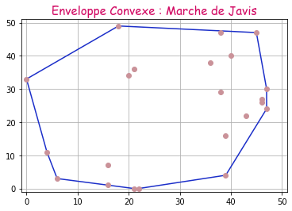

```python
test=creePoint() #cree un nouveau tableau de points
fig1=figure() #declare l'existence de la figure
i=0

c1=couleur_random() #cree une nouvelle couleur
c2=couleur_random() #cree une nouvelle couleur
c3=couleur_random() #cree une nouvelle couleur

g, =plot([],[],color=c1) #indique l'existence d'une ligne g dans la figure

#Initialisation
while i<len(test):
    X=[test[i][0]]
    Y=[test[i][1]]
    f, =plot(X,Y,marker="o",color=c2)
    i+=1

font1={"family" : "fantasy", 'color' : c3,"size":15}
title("Enveloppe Convexe : Marche de Javis", fontdict=font1)
ylim(-1, 51)
xlim(-1, 51)
grid(True)
n=0

#Affichage
ani = animation.FuncAnimation(fig1, Animation , n+(len(ArbreC_annim(test)))+1)
HTML(ani.to_jshtml())
```

Nous voyont dans l'exemple ci-dessus que nos fonctions ont bien fonctionné !!

Faisons d'autre tests pour mieux voir !!

[figure not shown]

Once Loop Reflect

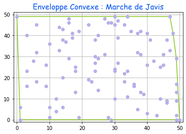

```python
test=creePoint() #cree un nouveau tableau de points
fig2=figure() #declare l'existence de la figure
i=0

c1=couleur_random() #cree une nouvelle couleur
c2=couleur_random() #cree une nouvelle couleur
c3=couleur_random() #cree une nouvelle couleur

g, =plot([],[],color=c1) #indique l'existence d'une ligne g dans la figure

#Initialisation
while i<len(test):
    X=[test[i][0]]
    Y=[test[i][1]]
    f, =plot(X,Y,marker="o",color=c2)
    i+=1

font1={"family" : "fantasy", 'color' : c3,"size":15}
title("Enveloppe Convexe : Marche de Javis", fontdict=font1)
ylim(-1, 51)
xlim(-1, 51)
grid(True)
n=0

#Affichage
ani = animation.FuncAnimation(fig2, Animation , n+(len(ArbreC_annim(test)))+1)
HTML(ani.to_jshtml())
```

Dans celle ci-dessus nous pouvons voir que l'enveloppe fait presque tout le graphe visible car il a beaucoup de points aux extrémités ce qui englobe bien le reste des points !

Faisons encore un autre test !!

[figure not shown]

Once Loop Reflect

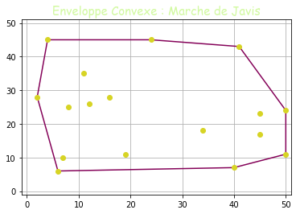

```python
test=creePoint() #cree un nouveau tableau de points
fig3=figure() #declare l'existence de la figure
i=0

c1=couleur_random() #cree une nouvelle couleur
c2=couleur_random() #cree une nouvelle couleur
c3=couleur_random() #cree une nouvelle couleur

g, =plot([],[],color=c1) #indique l'existence d'une ligne g dans la figure

#Initialisation
while i<len(test):
    X=[test[i][0]]
    Y=[test[i][1]]
    f, =plot(X,Y,marker="o",color=c2)
    i+=1

font1={"family" : "fantasy", 'color' : c3,"size":15}
title("Enveloppe Convexe : Marche de Javis", fontdict=font1)
ylim(-1, 51)
xlim(-1, 51)
grid(True)
n=0

#Affichage
ani = animation.FuncAnimation(fig3, Animation , n+(len(ArbreC_annim(test)))+1)
HTML(ani.to_jshtml())
```

**Conclusion :**

L'Enveloppe Convexe : La Marche de Javis a été difficile à mettre en place car on n'a pas vraiment trouvé quoique se soit qui pourrait nous aider donc il nous a fallu certainement plus de temps que prévu d'où la pauvreté du rendu. Nous aurions préféré pouvoir rendre une animation qui fait comme celle au début du devoir et ne pas à avoir se contenter de cela.

Nous avons donné notre maximum dans ce travail à cause de complications du côté privées des deux côtés.

Nous espèrerons que ce travail vous a quand même satisfait.

Nous avons pas réussie a faire du LaTex du à ces problèmes de temps, nous nous excusons pour cela.

**Nous vous souhaitons bonne continuation !!**